# **🌟 IBM HR Analytics Employee Attrition & Performance 🌟**

### Author: Kumod Sharma .📄🖋️

[figure not shown]

# **🎬 Introduction 🎬**

### 📊 Problem Statement:

1. The **high rate of employee attrition** can have significant implications for organizations, **leading to increased recruitment and training costs, reduced productivity, and decreased employee morale.**  
2. It is **crucial for companies** to understand the **underlying factors contributing to attrition and take proactive measures** to address them.

### 📊 Project Objective:

1. The **objective** of this project is to perform an **Exploratory Data Analysis (EDA)** on the **IBM HR Analytics Employee Attrition & Performance** dataset using Python.  
2. The **goal is to gain insights** into the **factors influencing employee attrition and performance** within the organization.  
3. By examining various features and **conducting statistical analysis**, we aim to identify patterns, trends, and potential areas for **improvement** that can help the company better understand and **manage employee attrition and performance.**

# **📝 Project Contents 📝**

### 📊 Table of Contents:

1. **Importing Libraries:** - Import all the essentials libraries for Data Manipulation,Visualization & Data Analysis.  
2. **Loading Dataset:** - Load the dataset into a **suitable data structure using pandas.**  
3. **Data Wrangling:** - To **clean, transform, and restructure** the data in order to make it suitable for analysis and **derive meaningful insights.**  
4. **Exploatory Data Analysis:** - To gain **insights, discover patterns,** and understand the characteristics of the data before applying further analysis.  
5. **Statistical Analysis:** - To assess the significance and **impact of different features on the target variable,** identify the most important variables.  
6. **Conclusion:** - Conclude the project by summarizing the **key findings and limitations related to employee attrition.**  
7. **Recommendations:** - Provide **suggestions based on key-findings** to **reduce employee attrition** in the organization in future.

# **📚 Importing Libraries 📚**

```python
# Libray for Data Manipulation.
import numpy as np
import pandas as pd

#Library for Data Visualization.
import altair as alt
import seaborn as sns
import matplotlib.pyplot as plt
sns.set(style="white",font_scale=1.5)
sns.set(rc={"axes.facecolor":"#FFFAF0","figure.facecolor":"#FFFAF0"})
sns.set_context("poster",font_scale = .7)

# Library to perform Statistical Analysis.
from scipy import stats
from scipy.stats import chi2
from scipy.stats import chi2_contingency


# Library to Display whole Dataset.
pd.set_option("display.max.columns",None)
pd.set_option("display.max.rows",None)

# Library to overcome Warnings.
import warnings
warnings.filterwarnings("ignore")
```

# **⏳ Loading Datset ⏳**

```python
df = pd.read_csv("C://Users//kumod sharma//Desktop/WA_Fn-UseC_-HR-Employee-Attrition.csv", sep = ',', header = 0)
```

```python
df.head().style.set_properties(**{'background-color': '#E9F6E2','color': 'black','border-color': '#8b8c8c'})
```

|  | Age | Attrition | BusinessTravel | DailyRate | Department | DistanceFromHome | Education | EducationField | EmployeeCount | EmployeeNumber | EnvironmentSatisfaction | Gender | HourlyRate | JobInvolvement | JobLevel | JobRole | JobSatisfaction | MaritalStatus | MonthlyIncome | MonthlyRate | NumCompaniesWorked | Over18 | OverTime | PercentSalaryHike | PerformanceRating | RelationshipSatisfaction | StandardHours | StockOptionLevel | TotalWorkingYears | … |
| --- | --- | --- | --- | --- | --- | --- | --- | --- | --- | --- | --- | --- | --- | --- | --- | --- | --- | --- | --- | --- | --- | --- | --- | --- | --- | --- | --- | --- | --- | --- |
| 0 | 41 | Yes | Travel_Rarely | 1102 | Sales | 1 | 2 | Life Sciences | 1 | 1 | 2 | Female | 94 | 3 | 2 | Sales Executive | 4 | Single | 5993 | 19479 | 8 | Y | Yes | 11 | 3 | 1 | 80 | 0 | 8 | … |
| 1 | 49 | No | Travel_Frequently | 279 | Research & Development | 8 | 1 | Life Sciences | 1 | 2 | 3 | Male | 61 | 2 | 2 | Research Scientist | 2 | Married | 5130 | 24907 | 1 | Y | No | 23 | 4 | 4 | 80 | 1 | 10 | … |
| 2 | 37 | Yes | Travel_Rarely | 1373 | Research & Development | 2 | 2 | Other | 1 | 4 | 4 | Male | 92 | 2 | 1 | Laboratory Technician | 3 | Single | 2090 | 2396 | 6 | Y | Yes | 15 | 3 | 2 | 80 | 0 | 7 | … |
| 3 | 33 | No | Travel_Frequently | 1392 | Research & Development | 3 | 4 | Life Sciences | 1 | 5 | 4 | Female | 56 | 3 | 1 | Research Scientist | 3 | Married | 2909 | 23159 | 1 | Y | Yes | 11 | 3 | 3 | 80 | 0 | 8 | … |
| 4 | 27 | No | Travel_Rarely | 591 | Research & Development | 2 | 1 | Medical | 1 | 7 | 1 | Male | 40 | 3 | 1 | Laboratory Technician | 2 | Married | 3468 | 16632 | 9 | Y | No | 12 | 3 | 4 | 80 | 1 | 6 | … |

# **🧾 Dataset Features Description 🧾**

| STT | Attribute Name | Meaning |
| --- | --- | --- |
| 1 | Age | Employee's age |
| 2 | Gender | Employee's Gender |
| 3 | BusinessTravel | Frequency of employees' business trips |
| 4 | DailyRate | Daily salary rate for employees |
| 5 | Department | Office of employees |
| 6 | DistanceFromHome | Distance from home in miles to work |
| 7 | Education | Level of education achieved by staff |
| 8 | EducationField | Employee's field of study |
| 9 | EmployeeCount | Total number of employees in the organization |
| 10 | EmployeeNumber | A unique identifier for each employee record |
| 11 | EnvironmentSatisfaction | Employee satisfaction with their working environment |
| 12 | HourlyRate | Hourly rate for employees |
| 13 | JobInvolvement | Level of involvement required for the employee's job |
| 14 | JobLevel | Employee's level of work |
| 15 | JobRole | The role of employees in the organization |
| 16 | JobSatisfaction | Employee satisfaction with their work |
| 17 | MaritalStatus | Employee's marital status |
| 18 | MonthlyIncome | Employee's monthly income |
| 19 | MonthlyRate | Monthly salary rate for employees |
| 20 | NumCompaniesWorked | Number of companies the employee worked for |
| 21 | Over18 | Whether the employee is over 18 years old |
| 22 | OverTime | Do employees work overtime |
| 23 | PercentSalaryHike | Salary increase rate for employees |
| 24 | PerformanceRating | The performance rating of the employee |
| 25 | RelationshipSatisfaction | Employee satisfaction with their relationships |
| 26 | StandardHours | Standard working hours for employees |
| 27 | StockOptionLevel | Employee stock option level |
| 28 | TotalWorkingYears | Total number of years the employee has worked |
| 29 | TrainingTimesLastYear | Number of times employees were taken to training in the last year |
| 30 | WorkLifeBalance | Employees' perception of their work-life balance |
| 31 | YearsAtCompany | Number of years employees have been with the company |
| 32 | YearsInCurrentRole | Number of years the employee has been in their current role |
| 33 | YearsSinceLastPromotion | Number of years since employee's last promotion |
| 34 | YearsWithCurrManager | Number of years an employee has been with their current manager |
| 35 | Attrition | Does the employee leave the organization |

# **🛠 Data Wrangling.🛠**

### 1. Computing the Dimension of Dataset.

```python
df.shape
```

```
(1470, 35)
```

### 💬 Inference:

- There are total **1470 Records/Rows** in the dataset.  
- There are total **35 Features/columns** in the dataset.

### 2. Generating Basic Information of Attributes.

```python
df.info(verbose=False)
```

```
<class 'pandas.core.frame.DataFrame'>
RangeIndex: 1470 entries, 0 to 1469
Columns: 35 entries, Age to YearsWithCurrManager
dtypes: int64(26), object(9)
memory usage: 402.1+ KB
```

### 💬 Inference:

* There are only **26 Numerical Attributes** in the dataset. * On the other hand we have **9 Categorical Attributes.**

### 3. Showing A Random Sample of Dataset with only Numerical Features.

```python
df.select_dtypes(np.number).sample(5).style.set_properties(**{'background-color': '#E9F6E2',
                                                              'color': 'black','border-color': '#8b8c8c'})
```

|  | Age | DailyRate | DistanceFromHome | Education | EmployeeCount | EmployeeNumber | EnvironmentSatisfaction | HourlyRate | JobInvolvement | JobLevel | JobSatisfaction | MonthlyIncome | MonthlyRate | NumCompaniesWorked | PercentSalaryHike | PerformanceRating | RelationshipSatisfaction | StandardHours | StockOptionLevel | TotalWorkingYears | TrainingTimesLastYear | WorkLifeBalance | YearsAtCompany | YearsInCurrentRole | YearsSinceLastPromotion | YearsWithCurrManager |
| --- | --- | --- | --- | --- | --- | --- | --- | --- | --- | --- | --- | --- | --- | --- | --- | --- | --- | --- | --- | --- | --- | --- | --- | --- | --- | --- |
| 1454 | 45 | 374 | 20 | 3 | 1 | 2046 | 4 | 50 | 3 | 2 | 3 | 4850 | 23333 | 8 | 15 | 3 | 3 | 80 | 0 | 8 | 3 | 3 | 5 | 3 | 0 | 1 |
| 905 | 29 | 694 | 1 | 3 | 1 | 1264 | 4 | 87 | 2 | 4 | 4 | 16124 | 3423 | 3 | 14 | 3 | 2 | 80 | 2 | 9 | 2 | 2 | 7 | 7 | 1 | 7 |
| 1014 | 31 | 182 | 8 | 5 | 1 | 1430 | 1 | 93 | 3 | 4 | 2 | 16422 | 8847 | 3 | 11 | 3 | 3 | 80 | 0 | 9 | 3 | 4 | 3 | 2 | 1 | 0 |
| 513 | 20 | 1362 | 10 | 1 | 1 | 701 | 4 | 32 | 3 | 1 | 3 | 1009 | 26999 | 1 | 11 | 3 | 4 | 80 | 0 | 1 | 5 | 3 | 1 | 0 | 1 | 1 |
| 715 | 33 | 827 | 1 | 4 | 1 | 998 | 3 | 84 | 4 | 2 | 2 | 5488 | 20161 | 1 | 13 | 3 | 1 | 80 | 1 | 6 | 2 | 3 | 6 | 5 | 1 | 2 |

### 💬 Inference:

* Some of the numerical features are storing **cateegories labelled in numbers.** * So for better analysis we will **replace those labelled numerical values with appropriate categorical values.**

### 4. Labelling of Categories in Numerical Features.

- **Note:**
  - The values used below to label the categories is provided in the **dataset description** on kaggle.

```python
df["Education"] = df["Education"].replace({1:"Below College",2:"College",3:"Bachelor",4:"Master",5:"Doctor"})
```

```python
df["EnvironmentSatisfaction"] = df["EnvironmentSatisfaction"].replace({1:"Low",2:"Medium",3:"High",4:"Very High"})
```

```python
df["JobInvolvement"] = df["JobInvolvement"].replace({1:"Low",2:"Medium",3:"High",4:"Very High"})
```

```python
df["JobLevel"] = df["JobLevel"].replace({1:"Entry Level",2:"Junior Level",3:"Mid Level",4:"Senior Level",
                                         5:"Executive Level"})
```

```python
df["JobSatisfaction"] = df["JobSatisfaction"].replace({1:"Low",2:"Medium",3:"High",4:"Very High"})
```

```python
df["PerformanceRating"] = df["PerformanceRating"].replace({1:"Low",2:"Good",3:"Excellent",4:"Outstanding"})
```

```python
df["RelationshipSatisfaction"] = df["RelationshipSatisfaction"].replace({1:"Low",2:"Medium",3:"High",4:"Very High"})
```

```python
df["WorkLifeBalance"] = df["WorkLifeBalance"].replace({1:"Bad",2:"Good",3:"Better",4:"Best"})
```

### 5. Showing A Random Sample of Datatset with only Categorical Features.

```python
df.select_dtypes(include="O").sample(5).style.set_properties(**{'background-color': '#E9F6E2',
                                                                'color': 'black','border-color': '#8b8c8c'})
```

|  | Attrition | BusinessTravel | Department | Education | EducationField | EnvironmentSatisfaction | Gender | JobInvolvement | JobLevel | JobRole | JobSatisfaction | MaritalStatus | Over18 | OverTime | PerformanceRating | RelationshipSatisfaction | WorkLifeBalance |
| --- | --- | --- | --- | --- | --- | --- | --- | --- | --- | --- | --- | --- | --- | --- | --- | --- | --- |
| 852 | No | Travel_Rarely | Research & Development | Below College | Medical | Medium | Female | High | Entry Level | Laboratory Technician | Very High | Married | Y | No | Excellent | Low | Better |
| 964 | No | Travel_Rarely | Sales | College | Medical | High | Female | High | Junior Level | Sales Executive | Low | Single | Y | No | Excellent | Very High | Best |
| 1167 | Yes | Travel_Rarely | Sales | College | Medical | Low | Male | Low | Junior Level | Sales Executive | Very High | Divorced | Y | Yes | Excellent | Very High | Good |
| 155 | No | Non-Travel | Research & Development | Below College | Technical Degree | Very High | Male | High | Junior Level | Manufacturing Director | High | Married | Y | No | Excellent | Low | Better |
| 274 | No | Travel_Rarely | Research & Development | College | Medical | Very High | Male | Medium | Entry Level | Research Scientist | High | Single | Y | No | Excellent | Low | Best |

### 6. Checking if There's Any Duplicate Records.

```python
have_duplicate_rows = df.duplicated().any()
have_duplicate_rows
```

```
False
```

### 💬 Inference:

* Since the **output is False**, we can say that there's **No Duplicate Records** present in the Dataset.

### 7. Computing Total No. of Missing Values and the Percentage of Missing Values.

```python
missing_df = df.isnull().sum().to_frame().rename(columns={0:"Total No. of Missing Values"})
missing_df["% of Missing Values"] = round((missing_df["Total No. of Missing Values"]/len(df))*100,2)
missing_df
```

|  | Total No. of Missing Values | % of Missing Values |
| --- | --- | --- |
| Age | 0 | 0.0 |
| Attrition | 0 | 0.0 |
| BusinessTravel | 0 | 0.0 |
| DailyRate | 0 | 0.0 |
| Department | 0 | 0.0 |
| DistanceFromHome | 0 | 0.0 |
| Education | 0 | 0.0 |
| EducationField | 0 | 0.0 |
| EmployeeCount | 0 | 0.0 |
| EmployeeNumber | 0 | 0.0 |
| EnvironmentSatisfaction | 0 | 0.0 |
| Gender | 0 | 0.0 |
| HourlyRate | 0 | 0.0 |
| JobInvolvement | 0 | 0.0 |
| JobLevel | 0 | 0.0 |
| JobRole | 0 | 0.0 |
| JobSatisfaction | 0 | 0.0 |
| MaritalStatus | 0 | 0.0 |
| MonthlyIncome | 0 | 0.0 |
| MonthlyRate | 0 | 0.0 |
| NumCompaniesWorked | 0 | 0.0 |
| Over18 | 0 | 0.0 |
| OverTime | 0 | 0.0 |
| PercentSalaryHike | 0 | 0.0 |
| PerformanceRating | 0 | 0.0 |
| RelationshipSatisfaction | 0 | 0.0 |
| StandardHours | 0 | 0.0 |
| StockOptionLevel | 0 | 0.0 |
| TotalWorkingYears | 0 | 0.0 |
| TrainingTimesLastYear | 0 | 0.0 |
| WorkLifeBalance | 0 | 0.0 |
| YearsAtCompany | 0 | 0.0 |
| YearsInCurrentRole | 0 | 0.0 |
| YearsSinceLastPromotion | 0 | 0.0 |
| YearsWithCurrManager | 0 | 0.0 |

### 💬 Inference:

* **None of the Attributes** are having **Missing Values.** * Since there's **no missing values** our **further analysis** will be **consistent** and **unbaised.**

### 8. Performing Descriptive Analysis on Numerical Attributes.

### 💬 Note:

* **`Count`**: It shows the number of values that are not missing in each of the column. * **`Mean`** : It shows the average of the values in each of the column. * **`Std`** : It shows standard deviation of the values in each of the column. * **`Min`** : It shows the smallest value in each of the column. * **`Max`** : It shows the maximum value in each of the column. * **`25%`**, **`50%`**, **`75%`** : The **`values`** correspond to the data divisions of **`25%`**, **`50%`** and **`75%`** **`percentiles`**.

```python
df.describe().T
```

|  | count | mean | std | min | 25% | 50% | 75% | max |
| --- | --- | --- | --- | --- | --- | --- | --- | --- |
| Age | 1470.0 | 36.923810 | 9.135373 | 18.0 | 30.00 | 36.0 | 43.00 | 60.0 |
| DailyRate | 1470.0 | 802.485714 | 403.509100 | 102.0 | 465.00 | 802.0 | 1157.00 | 1499.0 |
| DistanceFromHome | 1470.0 | 9.192517 | 8.106864 | 1.0 | 2.00 | 7.0 | 14.00 | 29.0 |
| EmployeeCount | 1470.0 | 1.000000 | 0.000000 | 1.0 | 1.00 | 1.0 | 1.00 | 1.0 |
| EmployeeNumber | 1470.0 | 1024.865306 | 602.024335 | 1.0 | 491.25 | 1020.5 | 1555.75 | 2068.0 |
| HourlyRate | 1470.0 | 65.891156 | 20.329428 | 30.0 | 48.00 | 66.0 | 83.75 | 100.0 |
| MonthlyIncome | 1470.0 | 6502.931293 | 4707.956783 | 1009.0 | 2911.00 | 4919.0 | 8379.00 | 19999.0 |
| MonthlyRate | 1470.0 | 14313.103401 | 7117.786044 | 2094.0 | 8047.00 | 14235.5 | 20461.50 | 26999.0 |
| NumCompaniesWorked | 1470.0 | 2.693197 | 2.498009 | 0.0 | 1.00 | 2.0 | 4.00 | 9.0 |
| PercentSalaryHike | 1470.0 | 15.209524 | 3.659938 | 11.0 | 12.00 | 14.0 | 18.00 | 25.0 |
| StandardHours | 1470.0 | 80.000000 | 0.000000 | 80.0 | 80.00 | 80.0 | 80.00 | 80.0 |
| StockOptionLevel | 1470.0 | 0.793878 | 0.852077 | 0.0 | 0.00 | 1.0 | 1.00 | 3.0 |
| TotalWorkingYears | 1470.0 | 11.279592 | 7.780782 | 0.0 | 6.00 | 10.0 | 15.00 | 40.0 |
| TrainingTimesLastYear | 1470.0 | 2.799320 | 1.289271 | 0.0 | 2.00 | 3.0 | 3.00 | 6.0 |
| YearsAtCompany | 1470.0 | 7.008163 | 6.126525 | 0.0 | 3.00 | 5.0 | 9.00 | 40.0 |
| YearsInCurrentRole | 1470.0 | 4.229252 | 3.623137 | 0.0 | 2.00 | 3.0 | 7.00 | 18.0 |
| YearsSinceLastPromotion | 1470.0 | 2.187755 | 3.222430 | 0.0 | 0.00 | 1.0 | 3.00 | 15.0 |
| YearsWithCurrManager | 1470.0 | 4.123129 | 3.568136 | 0.0 | 2.00 | 3.0 | 7.00 | 17.0 |

### 💬 Inference:

* The **Minimum `Age` is 18** which conveys that **All employees are Adult.** So there's **no need** of **`Over18` Attribute** for our analysis. * The **Stanard Deviation value of `EmployeeCount` and `StandardHours` is 0.00** which conveys that **All values present in this attribute are same**. * Attribute **`EmployeeNumber`** represents a **unique value to each of the employees**, which will not provide any meaningful inisghts. *Since this **Attribute** will not provide **any meaningful insights** in our analysis we can simply drop these attributes.

### 9. Dropping Attritbutes which doesn't imply any meaningful insights in our analysis.

```python
cols = ["Over18","EmployeeCount","EmployeeNumber","StandardHours"]

df.drop(columns=cols, inplace=True)
```

### 10. Performing Descriptive Analysis on Categorical Attributes.

### 💬 Note:

* **`Count`**: It shows the number of values that are not missing in each of the column. * **`Unique`** : It shows the number of unique values present in each of the ccolumn. * **`Top`** : It shows which categorical value is present most in each of the column. * **`Freq`** : It shows the frequency of the categorical value apperaing most in each of the columns.

```python
df.describe(include="O").T
```

|  | count | unique | top | freq |
| --- | --- | --- | --- | --- |
| Attrition | 1470 | 2 | No | 1233 |
| BusinessTravel | 1470 | 3 | Travel_Rarely | 1043 |
| Department | 1470 | 3 | Research & Development | 961 |
| Education | 1470 | 5 | Bachelor | 572 |
| EducationField | 1470 | 6 | Life Sciences | 606 |
| EnvironmentSatisfaction | 1470 | 4 | High | 453 |
| Gender | 1470 | 2 | Male | 882 |
| JobInvolvement | 1470 | 4 | High | 868 |
| JobLevel | 1470 | 5 | Entry Level | 543 |
| JobRole | 1470 | 9 | Sales Executive | 326 |
| JobSatisfaction | 1470 | 4 | Very High | 459 |
| MaritalStatus | 1470 | 3 | Married | 673 |
| OverTime | 1470 | 2 | No | 1054 |
| PerformanceRating | 1470 | 2 | Excellent | 1244 |
| RelationshipSatisfaction | 1470 | 4 | High | 459 |
| WorkLifeBalance | 1470 | 4 | Better | 893 |

### 💬 Inference:

* **All the categorical attributes** are having **low cardiniality.** * **`Attrition`** and **`OverTime**` column is **highly biased** towards **No Category.** * **`Businesstravel`** Attribute is **highly biased** towards **Travel_Rarely** category.

### 11. Checking Unique Values of Categorical Attributes.

```python
cat_cols = df.select_dtypes(include="O").columns

for column in cat_cols:
    print('Unique values of ', column, set(df[column]))
    print("-"*127)
```

```
Unique values of  Attrition {'No', 'Yes'}
-------------------------------------------------------------------------------------------------------------------------------
Unique values of  BusinessTravel {'Travel_Rarely', 'Non-Travel', 'Travel_Frequently'}
-------------------------------------------------------------------------------------------------------------------------------
Unique values of  Department {'Research & Development', 'Human Resources', 'Sales'}
-------------------------------------------------------------------------------------------------------------------------------
Unique values of  Education {'Bachelor', 'College', 'Master', 'Doctor', 'Below College'}
-------------------------------------------------------------------------------------------------------------------------------
Unique values of  EducationField {'Marketing', 'Technical Degree', 'Human Resources', 'Medical', 'Other', 'Life Sciences'}
-------------------------------------------------------------------------------------------------------------------------------
Unique values of  EnvironmentSatisfaction {'High', 'Very High', 'Medium', 'Low'}
-------------------------------------------------------------------------------------------------------------------------------
Unique values of  Gender {'Female', 'Male'}
-------------------------------------------------------------------------------------------------------------------------------
Unique values of  JobInvolvement {'High', 'Very High', 'Medium', 'Low'}
-------------------------------------------------------------------------------------------------------------------------------
Unique values of  JobLevel {'Entry Level', 'Junior Level', 'Senior Level', 'Mid Level', 'Executive Level'}
-------------------------------------------------------------------------------------------------------------------------------
Unique values of  JobRole {'Manager', 'Healthcare Representative', 'Human Resources', 'Manufacturing Director', 'Sales Representative', 'Research Director', 'Research Scientist', 'Laboratory Technician', 'Sales Executive'}
-------------------------------------------------------------------------------------------------------------------------------
Unique values of  JobSatisfaction {'High', 'Very High', 'Medium', 'Low'}
-------------------------------------------------------------------------------------------------------------------------------
Unique values of  MaritalStatus {'Single', 'Divorced', 'Married'}
-------------------------------------------------------------------------------------------------------------------------------
Unique values of  OverTime {'No', 'Yes'}
-------------------------------------------------------------------------------------------------------------------------------
Unique values of  PerformanceRating {'Outstanding', 'Excellent'}
-------------------------------------------------------------------------------------------------------------------------------
Unique values of  RelationshipSatisfaction {'High', 'Very High', 'Medium', 'Low'}
-------------------------------------------------------------------------------------------------------------------------------
Unique values of  WorkLifeBalance {'Best', 'Good', 'Bad', 'Better'}
-------------------------------------------------------------------------------------------------------------------------------
```

### 💬 Inference:

* The value set of the **categorical attributes is complete and easy to understand.** * So we do not need to perform preprocessing steps for these attributes.

# **📊 Exploratory Data Analysis.📊**

## 1. Visualizing the Employee Attrition Rate.

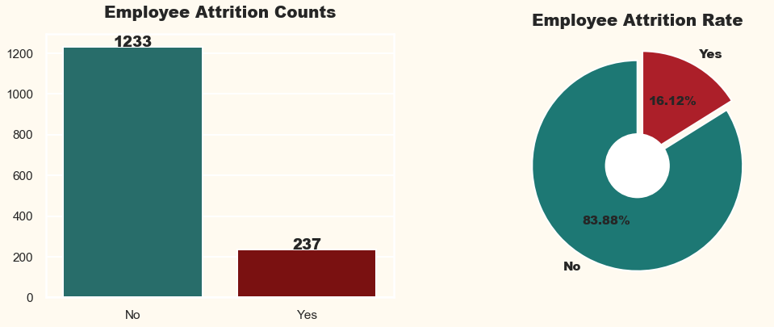

```python
#Visualization to show Employee Attrition in Counts.
plt.figure(figsize=(17,6))
plt.subplot(1,2,1)
attrition_rate = df["Attrition"].value_counts()
sns.barplot(attrition_rate.index,attrition_rate.values,palette=["#1d7874","#8B0000"])
plt.title("Employee Attrition Counts",fontweight="black",size=20,pad=20)
for i, v in enumerate(attrition_rate.values):
    plt.text(i, v, v,ha="center", fontweight='black', fontsize=18)

#Visualization to show Employee Attrition in Percentage.
plt.subplot(1,2,2)
plt.pie(attrition_rate, labels=["No","Yes"], autopct="%.2f%%", textprops={"fontweight":"black","size":15},
        colors = ["#1d7874","#AC1F29"],explode=[0,0.1],startangle=90)
center_circle = plt.Circle((0, 0), 0.3, fc='white')
fig = plt.gcf()
fig.gca().add_artist(center_circle)
plt.title("Employee Attrition Rate",fontweight="black",size=20,pad=10)
plt.show()
```

### 💬 Inference:

* The **employee attrition rate** of this organization **is 16.12%**. * According to **experts** in the field of **Human Resources**, says that the **attrition rate 4% to 6%** is **normal in organization.** * So we can say the **attrition rate** of the organization is at a **dangerous level**. * Therefore the **organization should take measures** to **reduce the attrition rate.**

## 2. Analyzing Employee Attrition by Gender.

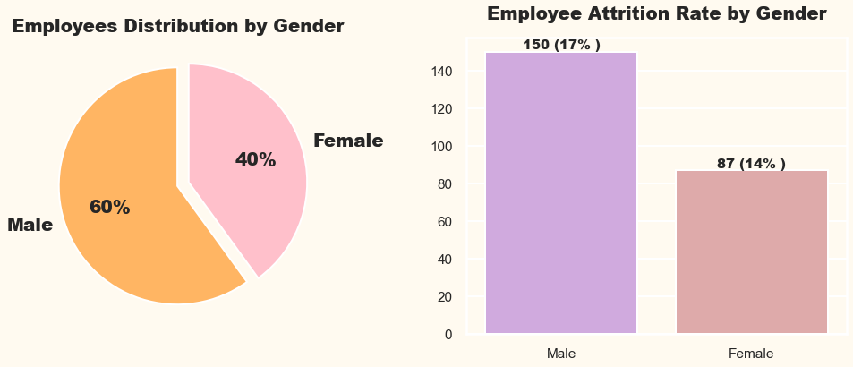

```python
#Visualization to show Total Employees by Gender.
plt.figure(figsize=(14,6))
plt.subplot(1,2,1)
gender_attrition = df["Gender"].value_counts()
plt.title("Employees Distribution by Gender",fontweight="black",size=20)
plt.pie(gender_attrition, autopct="%.0f%%",labels=gender_attrition.index,textprops=({"fontweight":"black","size":20}),
        explode=[0,0.1],startangle=90,colors= ["#ffb563","#FFC0CB"])


#Visualization to show Employee Attrition by Gender.
plt.subplot(1,2,2)
new_df = df[df["Attrition"]=="Yes"]
value_1 = df["Gender"].value_counts()
value_2 = new_df["Gender"].value_counts()
attrition_rate = np.floor((value_2/value_1)*100).values
sns.barplot(value_2.index, value_2.values,palette=["#D4A1E7","#E7A1A1"])
plt.title("Employee Attrition Rate by Gender",fontweight="black",size=20,pad=20)
for index,value in enumerate(value_2):
    plt.text(index,value,str(value)+" ("+str(int(attrition_rate[index]))+"% )",ha="center",va="bottom",
             size=15,fontweight="black")
plt.tight_layout()
plt.show()
```

### 💬 Inference:

* The number of **male employees** in the organization accounts for a higher proportion than **female employees** by **more than 20%**. * **Insight:** * **Male employees are leaving more** from the organization compared to **female employees.**

## 3. Analyzing Employee Attrition by Age.

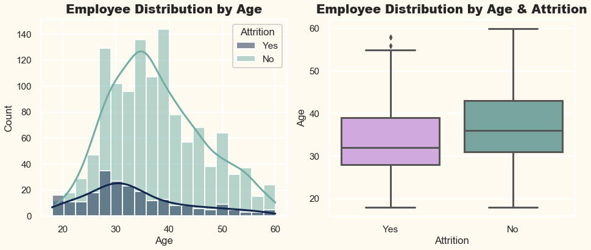

```python
#Visualization to show Employee Distribution by Age.
plt.figure(figsize=(13.5,6))
plt.subplot(1,2,1)
sns.histplot(x="Age",hue="Attrition",data=df,kde=True,palette=["#11264e","#6faea4"])
plt.title("Employee Distribution by Age",fontweight="black",size=20,pad=10)


#Visualization to show Employee Distribution by Age & Attrition.
plt.subplot(1,2,2)
sns.boxplot(x="Attrition",y="Age",data=df,palette=["#D4A1E7","#6faea4"])
plt.title("Employee Distribution by Age & Attrition",fontweight="black",size=20,pad=10)
plt.tight_layout()
plt.show()
```

### 💬 Inference:

* **Most** of the emloyees are between **age 30 to 40.** * We can clearly **observe a trend** that as the **age is increasing the attrition is decreasing.** * From the **boxplot** we can also observe that **the medain age** of employee who **left the organization is less** than the **employees who are working in the organization.** * **Insight:** * **Employees with young age leaves the company more compared to elder employees.**

## 3. Analyzing Employee Attrition by Business Travel.

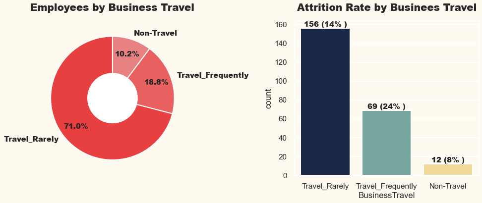

```python
#Visualization to show Total Employees by Businees Travel.
plt.figure(figsize=(14,6))
plt.subplot(1,2,1)
value_1 = df["BusinessTravel"].value_counts()
plt.title("Employees by Business Travel", fontweight="black", size=20, pad=20)
plt.pie(value_1.values, labels=value_1.index, autopct="%.1f%%",pctdistance=0.75,startangle=90,
        colors=['#E84040', '#E96060', '#E88181'],textprops={"fontweight":"black","size":15})
center_circle = plt.Circle((0, 0), 0.4, fc='white')
fig = plt.gcf()
fig.gca().add_artist(center_circle)

#Visualization to show Attrition Rate by Businees Travel.
plt.subplot(1,2,2)
new_df = df[df["Attrition"]=="Yes"]
value_2 = new_df["BusinessTravel"].value_counts().values
attrition_rate = np.floor((value_2/value_1)*100)
sns.countplot(new_df["BusinessTravel"],palette=["#11264e","#6faea4","#FEE08B"])
plt.title("Attrition Rate by Businees Travel",fontweight="black",size=20,pad=20)
for index,value in enumerate(value_2):
    plt.text(index,value,str(value)+" ("+str(int(attrition_rate[index]))+"% )",ha="center",va="bottom",
             size=15,fontweight="black")
plt.tight_layout()
plt.show()
```

### 💬 Inference:

* **Most** of the employees in the organization **Travel Rarely.** * **Highest employee attrition** can be observed by those employees who **Travels Frequently.** * **Lowest employee attrition** can be observed by those employees who are **Non-Travel.**

### 💬 Solution:

* The organization can **split travelling** among the employees to **reduce the burden of employees who travel frequently** * This will definitely **help in reduicing the attrition rate** eith respect to **business travel.**

## 4. Analyzing Employee Attrition by Department.

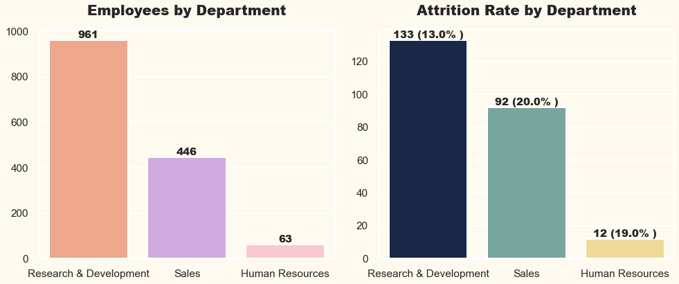

```python
#Visualization to show Total Employees by Department.
plt.figure(figsize=(14,6))
plt.subplot(1,2,1)
value_1 = df["Department"].value_counts()
sns.barplot(value_1.index, value_1.values,palette = ["#FFA07A", "#D4A1E7", "#FFC0CB"])
plt.title("Employees by Department",fontweight="black",size=20,pad=20)
for index,value in enumerate(value_1.values):
    plt.text(index,value,value,ha="center",va="bottom",fontweight="black",size=15,)

#Visualization to show Employee Attrition Rate by Department.
plt.subplot(1,2,2)
new_df = df[df["Attrition"]=="Yes"]
value_2 = new_df["Department"].value_counts()
attrition_rate = np.floor((value_2/value_1)*100).values
sns.barplot(value_2.index, value_2.values,palette=["#11264e","#6faea4","#FEE08B"])
plt.title("Attrition Rate by Department",fontweight="black",size=20,pad=20)
for index,value in enumerate(value_2):
    plt.text(index,value,str(value)+" ("+str(attrition_rate[index])+"% )",ha="center",va="bottom",
             size=15,fontweight="black")
plt.tight_layout()
plt.show()
```

### 💬 Inference:

* **Most** of the employees are from **Research & Development** Department. * **Highest Attrition** is in the **Sales** Department. * **Human Resources** Department **Attrition rate is also very high.** * **Insight:** * Though of **highest employees** in **Research & Development** department there is **least attrition** compared to other departments.

## 5. Analyzing Employee Attrition by DailyRate.

- **Note:**
  1. **DailyRate** shows the Daily salary rate for employees.
  2. To **generate meaningful insights** we can cut **Daily Rates** into three groups for meaningful analysis.

```python
df["DailyRate"].describe().to_frame().T
```

|  | count | mean | std | min | 25% | 50% | 75% | max |
| --- | --- | --- | --- | --- | --- | --- | --- | --- |
| DailyRate | 1470.0 | 802.485714 | 403.5091 | 102.0 | 465.0 | 802.0 | 1157.0 | 1499.0 |

```python
# Define the bin edges for the groups
bin_edges = [0, 500, 1000, 1500]

# Define the labels for the groups
bin_labels = ['Low DailyRate', 'Average DailyRate', 'High DailyRate']

# Cut the DailyRate column into groups
df['DailyRateGroup'] = pd.cut(df['DailyRate'], bins=bin_edges, labels=bin_labels)
```

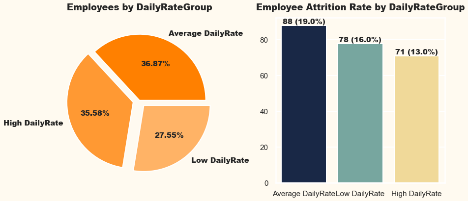

```python
##Visualization to show Total Employees by DailyRateGroup.
plt.figure(figsize=(13,6))
plt.subplot(1,2,1)
value_1 = df["DailyRateGroup"].value_counts()
plt.pie(value_1.values, labels=value_1.index,autopct="%.2f%%",textprops={"fontweight":"black","size":15},
        explode=[0,0.1,0.1],colors= ['#FF8000', '#FF9933', '#FFB366', '#FFCC99'])
plt.title("Employees by DailyRateGroup",fontweight="black",pad=15,size=18)


#Visualization to show Attrition Rate by DailyRateGroup.
plt.subplot(1,2,2)
new_df = df[df["Attrition"]=="Yes"]
value_2 = new_df["DailyRateGroup"].value_counts()
attrition_rate = np.floor((value_2/value_1)*100).values
sns.barplot(value_2.index.tolist(), value_2.values,palette=["#11264e","#6faea4","#FEE08B"])
plt.title("Employee Attrition Rate by DailyRateGroup",fontweight="black",pad=15,size=18)
for index,value in enumerate(value_2.values):
    plt.text(index,value, str(value)+" ("+str(attrition_rate[index])+"%)",ha="center",va="bottom",fontweight="black",size=15)

plt.tight_layout()
plt.show()
```

### 💬 Inference:

* Employees with **Average DailyRate** & **High Daily Rate** are **approxiamately equal.** * But the **attrition rate is very high of employees with average Daily Rate** compared to the employees with High DailyRate. * The **attrition rate is also high of employees with low DailyRate.** * **Insight:** * **Employees which are not getting High Daily Rate are mostly leaving the organization.**

## 6. Analyzing Employee Attrition by Distance From Home.

```python
print("Total Unique Values in Attribute is =>",df["DistanceFromHome"].nunique())
```

```
Total Unique Values in Attribute is => 29
```

```python
df["DistanceFromHome"].describe().to_frame().T
```

|  | count | mean | std | min | 25% | 50% | 75% | max |
| --- | --- | --- | --- | --- | --- | --- | --- | --- |
| DistanceFromHome | 1470.0 | 9.192517 | 8.106864 | 1.0 | 2.0 | 7.0 | 14.0 | 29.0 |

```python
# Define the bin edges for the groups
bin_edges = [0,2,5,10,30]

# Define the labels for the groups
bin_labels = ['0-2 kms', '3-5 kms', '6-10 kms',"10+ kms"]

# Cuttinf the DistaanceFromHome column into groups
df['DistanceGroup'] = pd.cut(df['DistanceFromHome'], bins=bin_edges, labels=bin_labels)
```

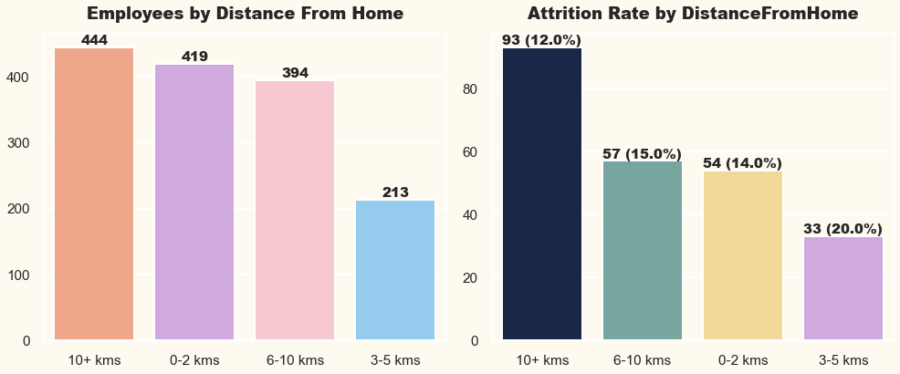

```python
##Visualization to show Total Employees by DistnaceFromHome.
plt.figure(figsize=(14,6))
plt.subplot(1,2,1)
value_1 = df["DistanceGroup"].value_counts()
sns.barplot(value_1.index.tolist(), value_1.values,palette = ["#FFA07A", "#D4A1E7", "#FFC0CB","#87CEFA"])
plt.title("Employees by Distance From Home",fontweight="black",pad=15,size=18)
for index, value in enumerate(value_1.values):
    plt.text(index,value,value,ha="center",va="bottom",fontweight="black",size=15)

#Visualization to show Attrition Rate by DistanceFromHome.
plt.subplot(1,2,2)
new_df = df[df["Attrition"]=="Yes"]
value_2 = new_df["DistanceGroup"].value_counts()
attrition_rate = np.floor((value_2/value_1)*100).values
sns.barplot(value_2.index.tolist(), value_2.values,palette=["#11264e","#6faea4","#FEE08B","#D4A1E7","#E7A1A1"])
plt.title("Attrition Rate by DistanceFromHome",fontweight="black",pad=15,size=18)
for index,value in enumerate(value_2.values):
    plt.text(index,value, str(value)+" ("+str(attrition_rate[index])+"%)",ha="center",va="bottom",fontweight="black",size=15)

plt.tight_layout()
plt.show()
```

## 7. Analyzing Employee Attrition by Education.

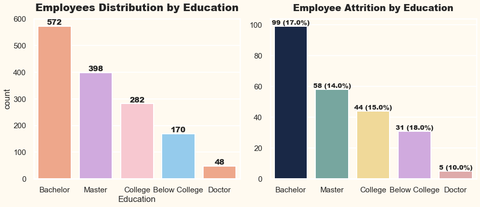

```python
#Visualization to show Total Employees by Education.
plt.figure(figsize=(13.5,6))
plt.subplot(1,2,1)
value_1 = df["Education"].value_counts()
sns.countplot(df["Education"],order=value_1.index,palette = ["#FFA07A", "#D4A1E7", "#FFC0CB","#87CEFA"])
plt.title("Employees Distribution by Education",fontweight="black",size=20,pad=15)
for index,value in enumerate(value_1.values):
    plt.text(index,value,value,ha="center",va="bottom",fontweight="black",size=15)

#Visualization to show Employee Attrition by Education.
plt.subplot(1,2,2)
value_2 = new_df["Education"].value_counts()
attrition_rate = np.floor((value_2/value_1)*100).values
sns.barplot(value_2.index,value_2.values,order=value_2.index,palette=["#11264e","#6faea4","#FEE08B","#D4A1E7","#E7A1A1"])
plt.title("Employee Attrition by Education",fontweight="black",size=18,pad=15)
for index,value in enumerate(value_2.values):
    plt.text(index,value,str(value)+" ("+str(attrition_rate[index])+"%)",ha="center",va="bottom",
             fontweight="black",size=13)
plt.tight_layout()
plt.show()
```

### 💬 Inference:

* **Most** of the employees in the organization have completed **Bachelors or Masters** as their **education** qualification. * **Very few** employees in the organization have completed **Doctorate degree** as their **education** qualification. * **Insights:** * we can observe a **trend of decreasisng in attrition rate** as the **education qualification increases.**

## 8. Analyzing Employee Attrition by Education Field.

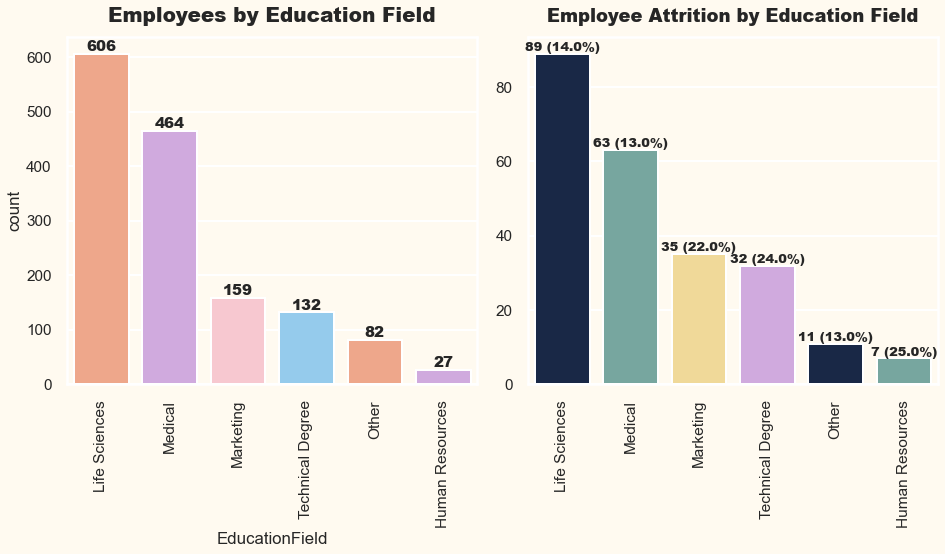

```python
#Visualization to show Total Employees by Education Field.
plt.figure(figsize=(13.5,8))
plt.subplot(1,2,1)
value_1 = df["EducationField"].value_counts()
sns.countplot(df["EducationField"],order=value_1.index,palette = ["#FFA07A", "#D4A1E7", "#FFC0CB","#87CEFA"])
plt.title("Employees by Education Field",fontweight="black",size=20,pad=15)
for index,value in enumerate(value_1.values):
    plt.text(index,value,value,ha="center",va="bottom",fontweight="black",size=15)
plt.xticks(rotation=90)

#Visualization to show Employee Attrition by Education Field.
plt.subplot(1,2,2)
value_2 = new_df["EducationField"].value_counts()
attrition_rate = np.floor((value_2/value_1)*100).values
sns.barplot(value_2.index,value_2.values,order=value_2.index,palette=["#11264e","#6faea4","#FEE08B","#D4A1E7"])
plt.title("Employee Attrition by Education Field",fontweight="black",size=18,pad=15)
for index,value in enumerate(value_2.values):
    plt.text(index,value,str(value)+" ("+str(attrition_rate[index])+"%)",ha="center",va="bottom",
             fontweight="black",size=13)
plt.xticks(rotation=90)
plt.tight_layout()
plt.show()
```

### 💬 Inference:

* **Most** of the employees are either from **Life Science or Medical** Education Field. * **Very few** employees are from **Human Resources** Education Field. * **Insight:** * Education Fields like **Human Resources, Marketing, Technical** is having **very high attrition rate.** * This may be because of **work load becuase there are very few employees** in these education fields compared to education field with less attrition rate.

## 9. Analyzing Employee Attrition by Environment Satisfaction.

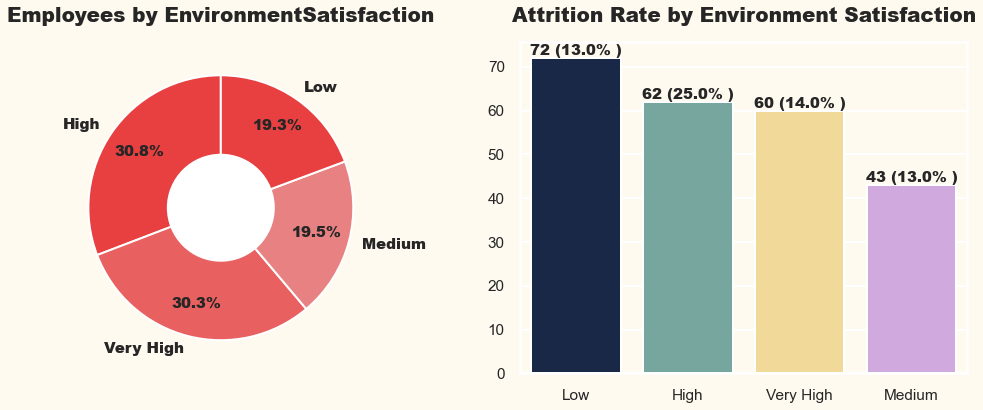

```python
#Visualization to show Total Employees by EnvironmentSatisfaction.
plt.figure(figsize=(14,6))
plt.subplot(1,2,1)
value_1 = df["EnvironmentSatisfaction"].value_counts()
plt.title("Employees by EnvironmentSatisfaction", fontweight="black", size=20, pad=20)
plt.pie(value_1.values, labels=value_1.index, autopct="%.1f%%",pctdistance=0.75,startangle=90,
        colors=['#E84040', '#E96060', '#E88181'],textprops={"fontweight":"black","size":15})
center_circle = plt.Circle((0, 0), 0.4, fc='white')
fig = plt.gcf()
fig.gca().add_artist(center_circle)


#Visualization to show Attrition Rate by EnvironmentSatisfaction.
plt.subplot(1,2,2)
new_df = df[df["Attrition"]=="Yes"]
value_2 = new_df["EnvironmentSatisfaction"].value_counts()
attrition_rate = np.floor((value_2/value_1)*100).values
sns.barplot(value_2.index,value_2.values,order=value_2.index,palette=["#11264e","#6faea4","#FEE08B","#D4A1E7","#E7A1A1"])
plt.title("Attrition Rate by Environment Satisfaction",fontweight="black",size=20,pad=20)
for index,value in enumerate(value_2):
    plt.text(index,value,str(value)+" ("+str(attrition_rate[index])+"% )",ha="center",va="bottom",
             size=15,fontweight="black")
plt.tight_layout()
plt.show()
```

## 10. Analyzing Employee Attrition by Job Roles.

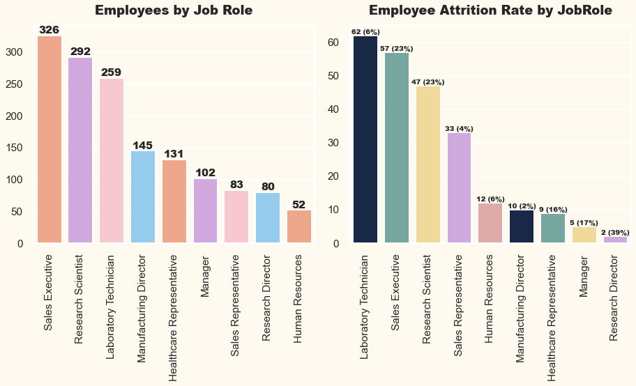

```python
##Visualization to show Total Employees by JobRole.
plt.figure(figsize=(13,8))
plt.subplot(1,2,1)
value_1 = df["JobRole"].value_counts()
sns.barplot(value_1.index.tolist(), value_1.values,palette = ["#FFA07A", "#D4A1E7", "#FFC0CB","#87CEFA"])
plt.title("Employees by Job Role",fontweight="black",pad=15,size=18)
plt.xticks(rotation=90)
for index, value in enumerate(value_1.values):
    plt.text(index,value,value,ha="center",va="bottom",fontweight="black",size=15)

#Visualization to show Attrition Rate by JobRole.
plt.subplot(1,2,2)
new_df = df[df["Attrition"]=="Yes"]
value_2 = new_df["JobRole"].value_counts()
attrition_rate = np.floor((value_2/value_1)*100).values
sns.barplot(value_2.index.tolist(), value_2.values,palette=["#11264e","#6faea4","#FEE08B","#D4A1E7","#E7A1A1"])
plt.title("Employee Attrition Rate by JobRole",fontweight="black",pad=15,size=18)
plt.xticks(rotation=90)
for index,value in enumerate(value_2.values):
    plt.text(index,value, str(value)+" ("+str(int(attrition_rate[index]))+"%)",ha="center",va="bottom",
             fontweight="black",size=10)

plt.tight_layout()
plt.show()
```

## 11. Analyzing Employee Attrition by Job Level.

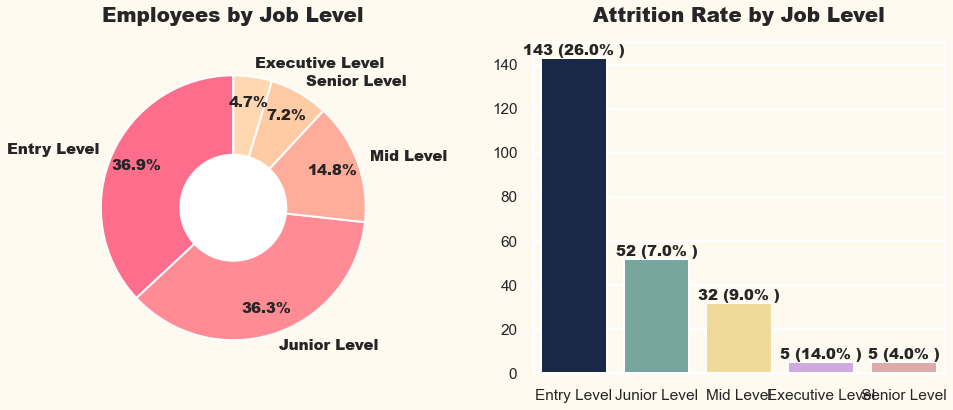

```python
#Visualization to show Total Employees by Job Level.
plt.figure(figsize=(14,6))
plt.subplot(1,2,1)
value_1 = df["JobLevel"].value_counts()
plt.title("Employees by Job Level", fontweight="black", size=20, pad=20)
plt.pie(value_1.values, labels=value_1.index, autopct="%.1f%%",pctdistance=0.8,startangle=90,
        colors=['#FF6D8C', '#FF8C94', '#FFAC9B', '#FFCBA4',"#FFD8B1"],textprops={"fontweight":"black","size":15})
center_circle = plt.Circle((0, 0), 0.4, fc='white')
fig = plt.gcf()
fig.gca().add_artist(center_circle)


#Visualization to show Attrition Rate by JobLevel.
plt.subplot(1,2,2)
new_df = df[df["Attrition"]=="Yes"]
value_2 = new_df["JobLevel"].value_counts()
attrition_rate = np.floor((value_2/value_1)*100).values
sns.barplot(value_2.index,value_2.values,order=value_2.index,palette=["#11264e","#6faea4","#FEE08B","#D4A1E7","#E7A1A1"])
plt.title("Attrition Rate by Job Level",fontweight="black",size=20,pad=20)
for index,value in enumerate(value_2):
    plt.text(index,value,str(value)+" ("+str(attrition_rate[index])+"% )",ha="center",va="bottom",
             size=15,fontweight="black")
plt.tight_layout()
plt.show()
```

## 12. Analyzing Employee Attrition by Job Satisfaction.

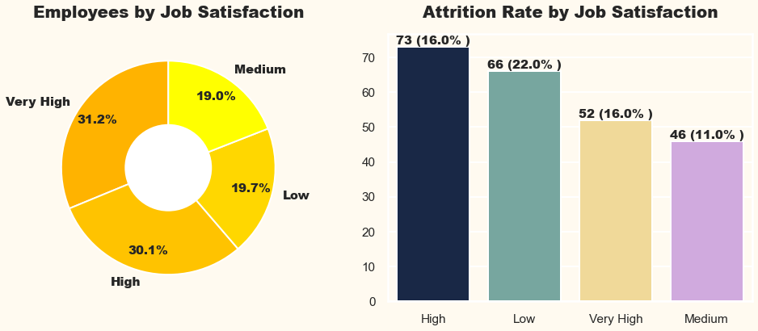

```python
#Visualization to show Total Employees by Job Satisfaction.
plt.figure(figsize=(14,6))
plt.subplot(1,2,1)
value_1 = df["JobSatisfaction"].value_counts()
plt.title("Employees by Job Satisfaction", fontweight="black", size=20, pad=20)
plt.pie(value_1.values, labels=value_1.index, autopct="%.1f%%",pctdistance=0.8,startangle=90,
        colors=['#FFB300', '#FFC300', '#FFD700', '#FFFF00'],textprops={"fontweight":"black","size":15})
center_circle = plt.Circle((0, 0), 0.4, fc='white')
fig = plt.gcf()
fig.gca().add_artist(center_circle)


#Visualization to show Attrition Rate by Job Satisfaction.
plt.subplot(1,2,2)
new_df = df[df["Attrition"]=="Yes"]
value_2 = new_df["JobSatisfaction"].value_counts()
attrition_rate = np.floor((value_2/value_1)*100).values
sns.barplot(value_2.index,value_2.values,order=value_2.index,palette=["#11264e","#6faea4","#FEE08B","#D4A1E7","#E7A1A1"])
plt.title("Attrition Rate by Job Satisfaction",fontweight="black",size=20,pad=20)
for index,value in enumerate(value_2):
    plt.text(index,value,str(value)+" ("+str(attrition_rate[index])+"% )",ha="center",va="bottom",
             size=15,fontweight="black")
plt.tight_layout()
plt.show()
```

### 💬 Inference:

* **Most** of the employees have rated their **job satisfaction** as **high or very high.** * **Insight:** * Employees who rated their job satisfaction low are **mostly leaving** the organization. * All the **categories** in job satisfaction is having **high** attrition rate.

## 13. Analyzing Employee Attrition by Marital Status.

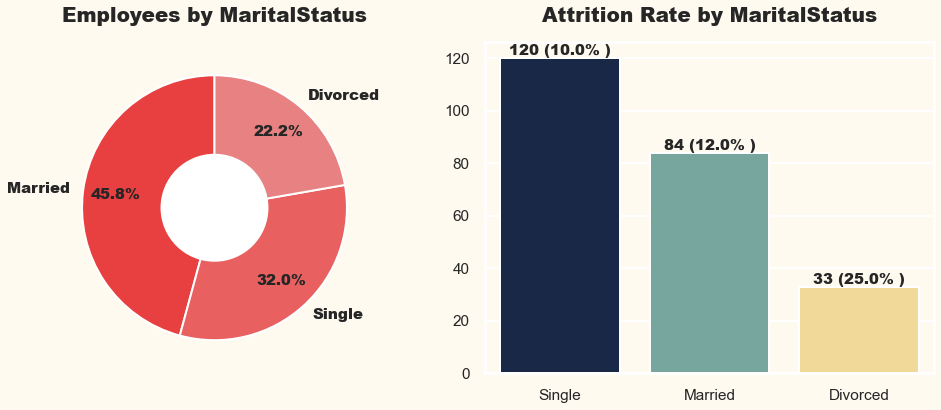

```python
#Visualization to show Total Employees by MaritalStatus.
plt.figure(figsize=(14,6))
plt.subplot(1,2,1)
value_1 = df["MaritalStatus"].value_counts()
plt.title("Employees by MaritalStatus", fontweight="black", size=20, pad=20)
plt.pie(value_1.values, labels=value_1.index, autopct="%.1f%%",pctdistance=0.75,startangle=90,
        colors=['#E84040', '#E96060', '#E88181', '#E7A1A1'],textprops={"fontweight":"black","size":15})
center_circle = plt.Circle((0, 0), 0.4, fc='white')
fig = plt.gcf()
fig.gca().add_artist(center_circle)


#Visualization to show Attrition Rate by MaritalStatus.
plt.subplot(1,2,2)
new_df = df[df["Attrition"]=="Yes"]
value_2 = new_df["MaritalStatus"].value_counts()
attrition_rate = np.floor((value_2/value_1)*100).values
sns.barplot(value_2.index, value_2.values,palette=["#11264e","#6faea4","#FEE08B","#D4A1E7","#E7A1A1"])
plt.title("Attrition Rate by MaritalStatus",
          fontweight="black",
          size=20,pad=20)
for index,value in enumerate(value_2):
    plt.text(index,value,str(value)+" ("+str(attrition_rate[index])+"% )",ha="center",va="bottom",
             size=15,fontweight="black")
plt.tight_layout()
plt.show()
```

## 14. Analyzing Employee Attrition by Monthly Income.

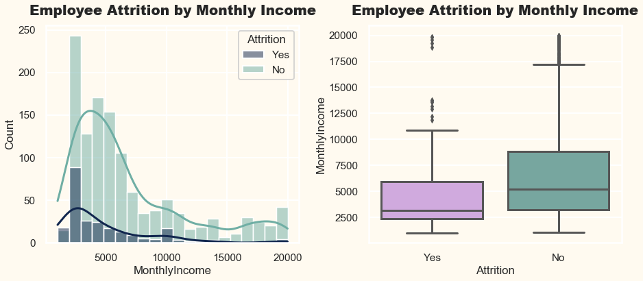

```python
#Visualization to show Employee Distribution by MonthlyIncome.
plt.figure(figsize=(13,6))
plt.subplot(1,2,1)
sns.histplot(x="MonthlyIncome", hue="Attrition", kde=True ,data=df,palette=["#11264e","#6faea4"])
plt.title("Employee Attrition by Monthly Income",fontweight="black",size=20,pad=15)

#Visualization to show Employee Attrition by Monthly Income.
plt.subplot(1,2,2)
sns.boxplot(x="Attrition",y="MonthlyIncome",data=df,palette=["#D4A1E7","#6faea4"])
plt.title("Employee Attrition by Monthly Income",fontweight="black",size=20,pad=15)
plt.tight_layout()
plt.show()
```

### 💬 Inference:

* **Most** of the employees are getting **paid less than 10000** in the organiation. * The **average monthly income of employee who have left** is **comparatively low** with employee who are still working. * **Insight:** * As the **Monthly Income increases the attrition decreases.**

## 15. Analyzing Employee Attrition by Monthly Rate.

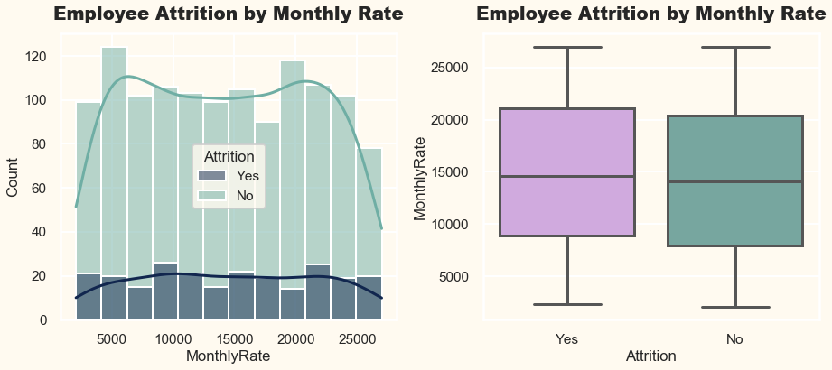

```python
plt.figure(figsize=(13,6))
plt.subplot(1,2,1)
sns.histplot(x="MonthlyRate", hue="Attrition", data=df,kde=True, palette=["#11264e","#6faea4"])
plt.title("Employee Attrition by Monthly Rate",fontweight="black",size=20,pad=15)

plt.subplot(1,2,2)
sns.boxplot(x="Attrition",y="MonthlyRate",data=df,palette=["#D4A1E7","#6faea4"])
plt.title("Employee Attrition by Monthly Rate",fontweight="black",size=20,pad=15)
plt.tight_layout()
plt.show()
```

### 💬 Inference:

* The **distribution of MonthlyRate is similar** througout the column. * So this feature **doesn't provide any meaningful insights** in the employee attrition.

## 16. Analyzing Employee Attrition by Number of Companies Worked.

```python
df["NumCompaniesWorked"].describe().to_frame().T
```

|  | count | mean | std | min | 25% | 50% | 75% | max |
| --- | --- | --- | --- | --- | --- | --- | --- | --- |
| NumCompaniesWorked | 1470.0 | 2.693197 | 2.498009 | 0.0 | 1.0 | 2.0 | 4.0 | 9.0 |

```python
# Define the bin edges for the groups
bin_edges = [0, 1, 3, 5, 10]

# Define the labels for the groups
bin_labels = ['0-1 Companies', '2-3 companies', '4-5 companies', "5+ companies"]

# Cut the DailyRate column into groups
df["NumCompaniesWorkedGroup"] = pd.cut(df['NumCompaniesWorked'], bins=bin_edges, labels=bin_labels)
```

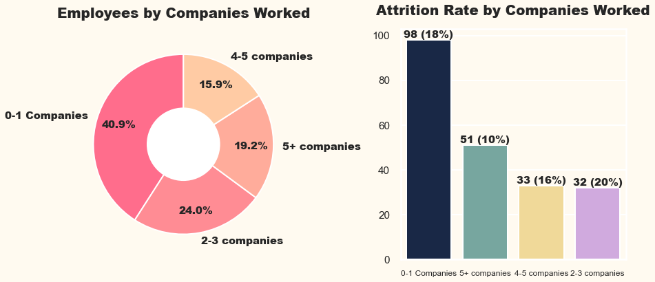

```python
#Visualization to show Total Employees by NumCompaniesWorked.
plt.figure(figsize=(13,6))
plt.subplot(1,2,1)
value_1 = df["NumCompaniesWorkedGroup"].value_counts()
plt.title("Employees by Companies Worked", fontweight="black", size=20, pad=20)
plt.pie(value_1.values, labels=value_1.index, autopct="%.1f%%",pctdistance=0.75,startangle=90,
        colors=['#FF6D8C', '#FF8C94', '#FFAC9B', '#FFCBA4'],textprops={"fontweight":"black","size":15})
center_circle = plt.Circle((0, 0), 0.4, fc='white')
fig = plt.gcf()
fig.gca().add_artist(center_circle)


#Visualization to show Attrition Rate by NumCompaniesWorked.
plt.subplot(1,2,2)
new_df = df[df["Attrition"]=="Yes"]
value_2 = new_df["NumCompaniesWorkedGroup"].value_counts()
attrition_rate = np.floor((value_2/value_1)*100).values
sns.barplot(value_2.index.tolist(), value_2.values,palette=["#11264e","#6faea4","#FEE08B","#D4A1E7","#E7A1A1"])
plt.title("Attrition Rate by Companies Worked",fontweight="black",size=20,pad=20)
for index,value in enumerate(value_2):
    plt.text(index,value,str(value)+" ("+str(int(attrition_rate[index]))+"%)",ha="center",va="bottom",
             size=15,fontweight="black")
plt.xticks(size=12)
plt.tight_layout()
plt.show()
```

## 17. Analyzing Employee Attrition by Over Time.

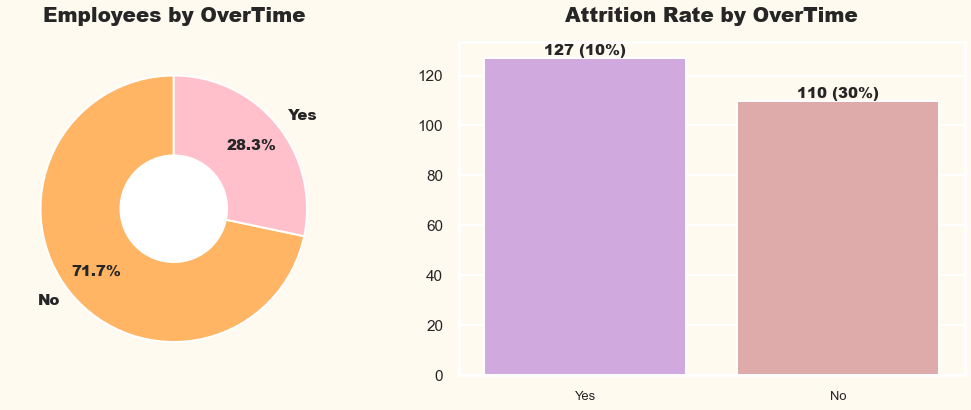

```python
#Visualization to show Total Employees by OverTime.
plt.figure(figsize=(15,6))
plt.subplot(1,2,1)
value_1 = df["OverTime"].value_counts()
plt.title("Employees by OverTime", fontweight="black", size=20, pad=20)
plt.pie(value_1.values, labels=value_1.index, autopct="%.1f%%",pctdistance=0.75,startangle=90,
        colors=["#ffb563","#FFC0CB"],textprops={"fontweight":"black","size":15})
center_circle = plt.Circle((0, 0), 0.4, fc='white')
fig = plt.gcf()
fig.gca().add_artist(center_circle)


#Visualization to show Attrition Rate by OverTime.
plt.subplot(1,2,2)
new_df = df[df["Attrition"]=="Yes"]
value_2 = new_df["OverTime"].value_counts()
attrition_rate = np.floor((value_2/value_1)*100).values
sns.barplot(value_2.index.tolist(), value_2.values,palette=["#D4A1E7","#E7A1A1"])
plt.title("Attrition Rate by OverTime",fontweight="black",size=20,pad=20)
for index,value in enumerate(value_2):
    plt.text(index,value,str(value)+" ("+str(int(attrition_rate[index]))+"%)",ha="center",va="bottom",
             size=15,fontweight="black")
plt.xticks(size=13)
plt.tight_layout()
plt.show()
```

## 18. Analyzing Employee Attrition by Percentage Salary Hike.

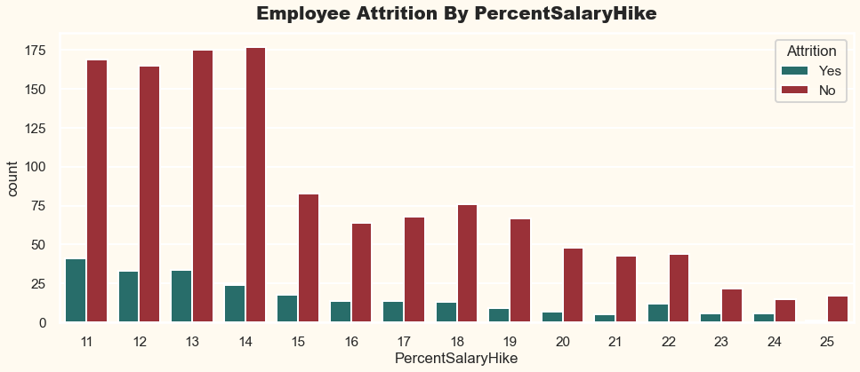

```python
#Visualization to show Employee Distribution by Percentage Salary Hike.
plt.figure(figsize=(16,6))
sns.countplot(x="PercentSalaryHike", hue="Attrition", data=df, palette=["#1d7874","#AC1F29"])
plt.title("Employee Attrition By PercentSalaryHike",fontweight="black",size=20,pad=15)
plt.show()
```

## 19. Analyzing Employee Attrition by Performance Rating.

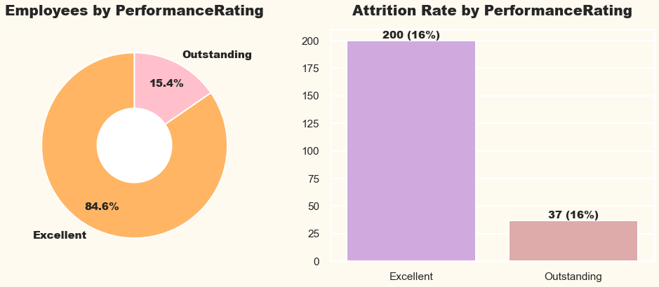

```python
#Visualization to show Total Employees by PerformanceRating.
plt.figure(figsize=(14,6))
plt.subplot(1,2,1)
value_1 = df["PerformanceRating"].value_counts()
plt.title("Employees by PerformanceRating", fontweight="black", size=20, pad=20)
plt.pie(value_1.values, labels=value_1.index, autopct="%.1f%%",pctdistance=0.75,startangle=90,
        colors=["#ffb563","#FFC0CB"],textprops={"fontweight":"black","size":15})
center_circle = plt.Circle((0, 0), 0.4, fc='white')
fig = plt.gcf()
fig.gca().add_artist(center_circle)


#Visualization to show Attrition Rate by PerformanceRating.
plt.subplot(1,2,2)
new_df = df[df["Attrition"]=="Yes"]
value_2 = new_df["PerformanceRating"].value_counts()
attrition_rate = np.floor((value_2/value_1)*100).values
sns.barplot(value_2.index.tolist(), value_2.values,palette=["#D4A1E7","#E7A1A1"])
plt.title("Attrition Rate by PerformanceRating",fontweight="black",size=20,pad=20)
for index,value in enumerate(value_2):
    plt.text(index,value,str(value)+" ("+str(int(attrition_rate[index]))+"%)",ha="center",va="bottom",
             size=15,fontweight="black")
plt.tight_layout()
plt.show()
```

### 💬 Inference:

* **Most** of the employees are having **excellent performance rating.** * Both the **categories** in this field is having **same attriton rate.** * That's why we can't generate any **meaningful inisghts**

## 20. Analyzing Employee Attrition by Relationship Satisfaction.

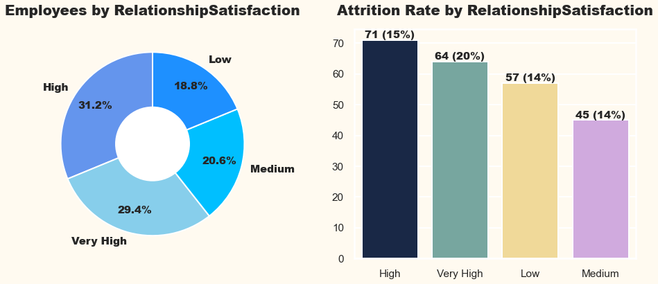

```python
#Visualization to show Total Employees by RelationshipSatisfaction.
plt.figure(figsize=(13,6))
plt.subplot(1,2,1)
value_1 = df["RelationshipSatisfaction"].value_counts()
plt.title("Employees by RelationshipSatisfaction", fontweight="black", size=20, pad=20)
plt.pie(value_1.values, labels=value_1.index, autopct="%.1f%%",pctdistance=0.75,startangle=90,
        colors=['#6495ED', '#87CEEB', '#00BFFF', '#1E90FF'],textprops={"fontweight":"black","size":15})
center_circle = plt.Circle((0, 0), 0.4, fc='white')
fig = plt.gcf()
fig.gca().add_artist(center_circle)


#Visualization to show Attrition Rate by RelationshipSatisfaction.
plt.subplot(1,2,2)
new_df = df[df["Attrition"]=="Yes"]
value_2 = new_df["RelationshipSatisfaction"].value_counts()
attrition_rate = np.floor((value_2/value_1)*100).values
sns.barplot(value_2.index, value_2.values,order=value_2.index,palette=["#11264e","#6faea4","#FEE08B","#D4A1E7","#E7A1A1"])
plt.title("Attrition Rate by RelationshipSatisfaction",fontweight="black",size=20,pad=20)
for index,value in enumerate(value_2):
    plt.text(index,value,str(value)+" ("+str(int(attrition_rate[index]))+"%)",ha="center",va="bottom",
             size=15,fontweight="black")
plt.tight_layout()
plt.show()
```

### 💬 Inference:

* **Most** of the employees are having **high or very high** relationship satisfaction. * **Insights:** * Though the **relationship satification is high** there's a **high attrition rate.** * All the **categories** in this feature is having a **high attriton rate.**

## 20. Analyzing Employee Attrition by Work Life Balance.

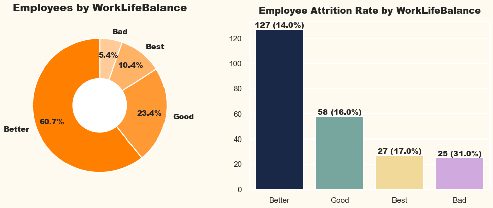

```python
##Visualization to show Total Employees by WorkLifeBalance.
plt.figure(figsize=(14.5,6))
plt.subplot(1,2,1)
value_1 = df["WorkLifeBalance"].value_counts()
plt.title("Employees by WorkLifeBalance", fontweight="black", size=20, pad=20)
plt.pie(value_1.values, labels=value_1.index, autopct="%.1f%%",pctdistance=0.75,startangle=90,
        colors= ['#FF8000', '#FF9933', '#FFB366', '#FFCC99'],textprops={"fontweight":"black","size":15})
center_circle = plt.Circle((0, 0), 0.4, fc='white')
fig = plt.gcf()
fig.gca().add_artist(center_circle)

#Visualization to show Attrition Rate by WorkLifeBalance.
plt.subplot(1,2,2)
new_df = df[df["Attrition"]=="Yes"]
value_2 = new_df["WorkLifeBalance"].value_counts()
attrition_rate = np.floor((value_2/value_1)*100).values
sns.barplot(value_2.index, value_2.values,order=value_2.index,palette=["#11264e","#6faea4","#FEE08B","#D4A1E7","#E7A1A1"])
plt.title("Employee Attrition Rate by WorkLifeBalance",fontweight="black",pad=15,size=18)
for index,value in enumerate(value_2.values):
    plt.text(index,value, str(value)+" ("+str(attrition_rate[index])+"%)",ha="center",va="bottom",
             fontweight="black",size=15)
plt.tight_layout()
plt.show()
```

### 💬 Inference:

* **More than 60%** of employees are having a **better work life balance.** * **Insight** * Employees with **Bad Work Life Balance** is having **Very High Attrition Rate.** * Other **Categories** is also having **High attriton Rate.**

## 21. Analyzing Employee Attrition by Total Working Years.

```python
# Define the bin edges for the groups
bin_edges = [0, 5, 10, 20, 50]

# Define the labels for the groups
bin_labels = ['0-5 years', '5-10 years', '10-20 years', "20+ years"]

# Cut the DailyRate column into groups
df["TotalWorkingYearsGroup"] = pd.cut(df['TotalWorkingYears'], bins=bin_edges, labels=bin_labels)
```

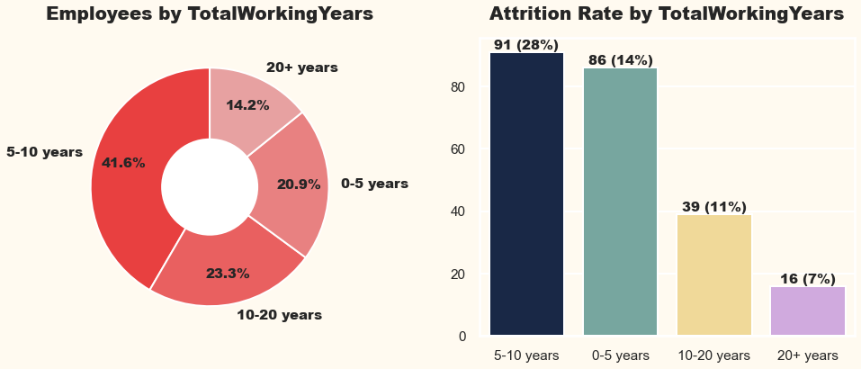

```python
#Visualization to show Total Employees by TotalWorkingYearsGroup.
plt.figure(figsize=(14,6))
plt.subplot(1,2,1)
value_1 = df["TotalWorkingYearsGroup"].value_counts()
plt.title("Employees by TotalWorkingYears", fontweight="black", size=20, pad=20)
plt.pie(value_1.values, labels=value_1.index, autopct="%.1f%%",pctdistance=0.75,startangle=90,
        colors=['#E84040', '#E96060', '#E88181', '#E7A1A1'],textprops={"fontweight":"black","size":15})
center_circle = plt.Circle((0, 0), 0.4, fc='white')
fig = plt.gcf()
fig.gca().add_artist(center_circle)


#Visualization to show Attrition Rate by TotalWorkingYearsGroup.
plt.subplot(1,2,2)
new_df = df[df["Attrition"]=="Yes"]
value_2 = new_df["TotalWorkingYearsGroup"].value_counts()
attrition_rate = np.floor((value_2/value_1)*100).values
sns.barplot(value_2.index.tolist(), value_2.values,palette=["#11264e","#6faea4","#FEE08B","#D4A1E7","#E7A1A1"])
plt.title("Attrition Rate by TotalWorkingYears",fontweight="black",size=20,pad=20)
for index,value in enumerate(value_2):
    plt.text(index,value,str(value)+" ("+str(int(attrition_rate[index]))+"%)",ha="center",va="bottom",
             size=15,fontweight="black")
plt.tight_layout()
plt.show()
```

### 💬 Inference:

* **Most** of tthe employees are having a total of **5 to 10 years** of working experience. But their **Attrition Rate** is also **very high.** * **Insights:** * Employee with **working experience of less than 10 years** are having **High Attrition Rate.** * Employee with **working experience of more than 10 years** are having **Less Attrition Rate.**

## 22. Analyzing Employee Attrition by Years at Company.

```python
# Define the bin edges for the groups
bin_edges = [0, 1, 5, 10, 20]

# Define the labels for the groups
bin_labels = ['0-1 years', '2-5 years', '5-10 years', "10+ years"]

# Cut the DailyRate column into groups
df["YearsAtCompanyGroup"] = pd.cut(df['YearsAtCompany'], bins=bin_edges, labels=bin_labels)
```

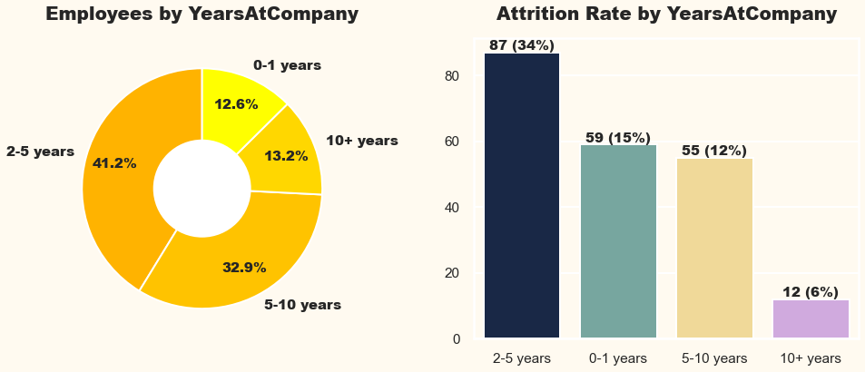

```python
#Visualization to show Total Employees by YearsAtCompanyGroup.
plt.figure(figsize=(14,6))
plt.subplot(1,2,1)
value_1 = df["YearsAtCompanyGroup"].value_counts()
plt.title("Employees by YearsAtCompany", fontweight="black", size=20, pad=20)
plt.pie(value_1.values, labels=value_1.index, autopct="%.1f%%",pctdistance=0.75,startangle=90,
        colors=['#FFB300', '#FFC300', '#FFD700', '#FFFF00'],textprops={"fontweight":"black","size":15})
center_circle = plt.Circle((0, 0), 0.4, fc='white')
fig = plt.gcf()
fig.gca().add_artist(center_circle)


#Visualization to show Attrition Rate by YearsAtCompanyGroup.
plt.subplot(1,2,2)
new_df = df[df["Attrition"]=="Yes"]
value_2 = new_df["YearsAtCompanyGroup"].value_counts()
attrition_rate = np.floor((value_2/value_1)*100).values
sns.barplot(value_2.index.tolist(), value_2.values,palette=["#11264e","#6faea4","#FEE08B","#D4A1E7","#E7A1A1"])
plt.title("Attrition Rate by YearsAtCompany",fontweight="black",size=20,pad=20)
for index,value in enumerate(value_2):
    plt.text(index,value,str(value)+" ("+str(int(attrition_rate[index]))+"%)",ha="center",va="bottom",
             size=15,fontweight="black")
plt.tight_layout()
plt.show()
```

### 💬 Inference:

* **Most** employees has worked for ** 2 to 10** years in the organization. * **Very few** employees has working for **less than 1 year** or **more than 10 years.** * **Insights** * Employee who have worked for **2-5** years are having **very high attrition rate.** * Employee who have worked for **10+** years are having **low attrition rate.**

## 23. Analyzing Employee Attrition by Years In Current Role.

```python
# Define the bin edges for the groups
bin_edges = [0, 1, 5, 10, 20]

# Define the labels for the groups
bin_labels = ['0-1 years', '2-5 years', '5-10 years', "10+ years"]

# Cut the DailyRate column into groups
df["YearsInCurrentRoleGroup"] = pd.cut(df['YearsInCurrentRole'], bins=bin_edges, labels=bin_labels)
```

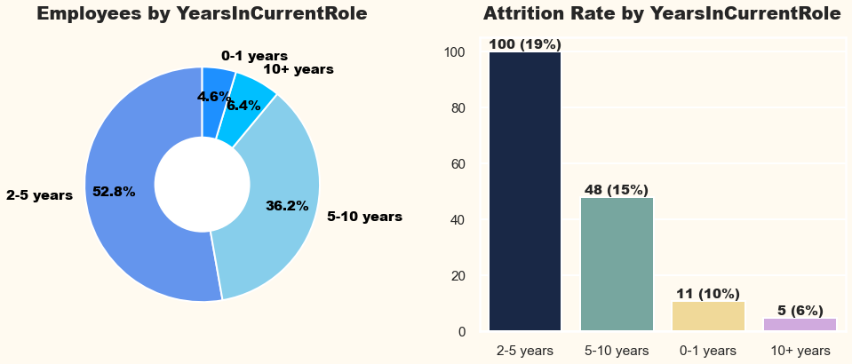

```python
#Visualization to show Total Employees by YearsInCurrentRoleGroup.
plt.figure(figsize=(14,6))
plt.subplot(1,2,1)
value_1 = df["YearsInCurrentRoleGroup"].value_counts()
plt.title("Employees by YearsInCurrentRole", fontweight="black", size=20, pad=20)
plt.pie(value_1.values, labels=value_1.index, autopct="%.1f%%",pctdistance=0.75,startangle=90,
        colors=['#6495ED', '#87CEEB', '#00BFFF', '#1E90FF'],textprops={"fontweight":"black","size":15,"color":"black"})
center_circle = plt.Circle((0, 0), 0.4, fc='white')
fig = plt.gcf()
fig.gca().add_artist(center_circle)


#Visualization to show Attrition Rate by YearsInCurrentRoleGroup.
plt.subplot(1,2,2)
new_df = df[df["Attrition"]=="Yes"]
value_2 = new_df["YearsInCurrentRoleGroup"].value_counts()
attrition_rate = np.floor((value_2/value_1)*100).values
sns.barplot(value_2.index.tolist(), value_2.values,palette= ["#11264e","#6faea4","#FEE08B","#D4A1E7","#E7A1A1"])
plt.title("Attrition Rate by YearsInCurrentRole",fontweight="black",size=20,pad=20)
for index,value in enumerate(value_2):
    plt.text(index,value,str(value)+" ("+str(int(attrition_rate[index]))+"%)",ha="center",va="bottom",
             size=15,fontweight="black")
plt.tight_layout()
plt.show()
```

### 💬 Inference:

* **Most** employees has worked for ** 2 to 10** years for **the same role** in the organization. * **Very few** employees has worked for **less than 1 year** or **more than 10 years** in the **same role.** * **Insights** * Employee who has worked for **2 to 0 years in the same role** are having **very high attrition rate.** * Employee who has worked for **10+ years in the same role** are having **low attrition rate.**

## 24. Analyzing Employee Attrition by Years Since Last Promotion.

```python
# Define the bin edges for the groups
bin_edges = [0, 1, 5, 10, 20]

# Define the labels for the groups
bin_labels = ['0-1 years', '2-5 years', '5-10 years', "10+ years"]

# Cut the DailyRate column into groups
df["YearsSinceLastPromotionGroup"] = pd.cut(df['YearsSinceLastPromotion'], bins=bin_edges, labels=bin_labels)
```

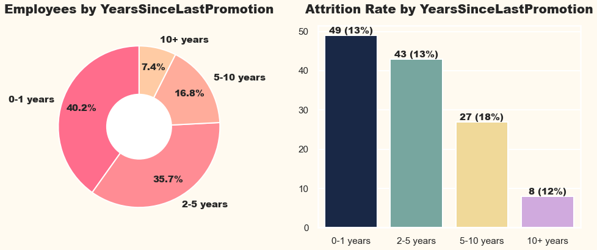

```python
#Visualization to show Total Employees by YearsSinceLastPromotionGroup.
plt.figure(figsize=(14,6))
plt.subplot(1,2,1)
value_1 = df["YearsSinceLastPromotionGroup"].value_counts()
plt.title("Employees by YearsSinceLastPromotion", fontweight="black", size=20, pad=20)
plt.pie(value_1.values, labels=value_1.index, autopct="%.1f%%",pctdistance=0.75,startangle=90,
        colors=['#FF6D8C', '#FF8C94', '#FFAC9B', '#FFCBA4'],textprops={"fontweight":"black","size":15})
center_circle = plt.Circle((0, 0), 0.4, fc='white')
fig = plt.gcf()
fig.gca().add_artist(center_circle)


#Visualization to show Attrition Rate by YearsSinceLastPromotionGroup.
plt.subplot(1,2,2)
new_df = df[df["Attrition"]=="Yes"]
value_2 = new_df["YearsSinceLastPromotionGroup"].value_counts()
attrition_rate = np.floor((value_2/value_1)*100).values
sns.barplot(value_2.index.tolist(), value_2.values,palette=["#11264e","#6faea4","#FEE08B","#D4A1E7","#E7A1A1"])

plt.title("Attrition Rate by YearsSinceLastPromotion",fontweight="black",size=20,pad=20)
for index,value in enumerate(value_2):
    plt.text(index,value,str(value)+" ("+str(int(attrition_rate[index]))+"%)",ha="center",va="bottom",
             size=15,fontweight="black")
plt.tight_layout()
plt.show()
```

## 25. Analyzing Employee Attrition by Years with Current Manager.

```python
# Define the bin edges for the groups
bin_edges = [0, 1, 5, 10, 20]

# Define the labels for the groups
bin_labels = ['0-1 years', '2-5 years', '5-10 years', "10+ years"]

# Cut the DailyRate column into groups
df["YearsWithCurrManagerGroup"] = pd.cut(df['YearsWithCurrManager'], bins=bin_edges, labels=bin_labels)
```

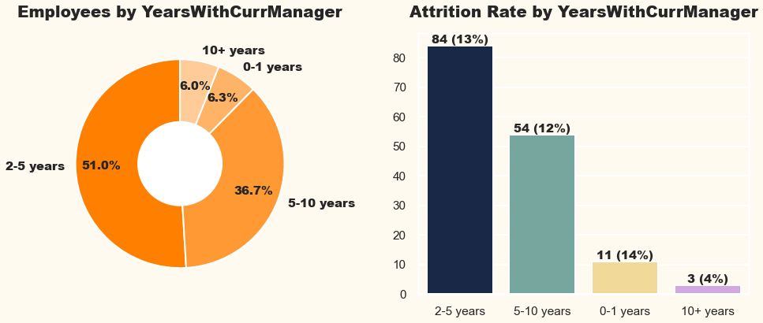

```python
#Visualization to show Total Employees by YearsWithCurrManagerGroup.
plt.figure(figsize=(14,6))
plt.subplot(1,2,1)
value_1 = df["YearsWithCurrManagerGroup"].value_counts()
plt.title("Employees by YearsWithCurrManager", fontweight="black", size=20, pad=20)
plt.pie(value_1.values, labels=value_1.index, autopct="%.1f%%",pctdistance=0.75,startangle=90,
        colors= ['#FF8000', '#FF9933', '#FFB366', '#FFCC99'],textprops={"fontweight":"black","size":15})
center_circle = plt.Circle((0, 0), 0.4, fc='white')
fig = plt.gcf()
fig.gca().add_artist(center_circle)


#Visualization to show Attrition Rate by YearsWithCurrManagerGroup.
plt.subplot(1,2,2)
new_df = df[df["Attrition"]=="Yes"]
value_2 = new_df["YearsWithCurrManagerGroup"].value_counts()
attrition_rate = np.floor((value_2/value_1)*100).values
sns.barplot(value_2.index.tolist(), value_2.values,palette=["#11264e","#6faea4","#FEE08B","#D4A1E7","#E7A1A1"])
plt.title("Attrition Rate by YearsWithCurrManager",fontweight="black",size=20,pad=20)
for index,value in enumerate(value_2):
    plt.text(index,value,str(value)+" ("+str(int(attrition_rate[index]))+"%)",ha="center",va="bottom",
             size=15,fontweight="black")
plt.tight_layout()
plt.show()
```

# **📈 Statistical Analysis - Feature Importance.📈**

## 1. Performing ANOVA Test to Analyze the Numerical Features Importance in Employee Attrition.

### 💬 Inference:

* **Anova test is used to Analyzing the impact of different numerical features on a response categorical feature.** * **Anova test** returns two statistical values **f_score** and **p_value** * **Note:** * A **larger F-score indicates a stronger association** between the independent variable(s) and the dependent variable. * If the **p-value is below your chosen significance level** (e.g., p less than 0.05),than we can reject our null hypothesis.

```python
num_cols = df.select_dtypes(np.number).columns
```

```python
new_df = df.copy()

new_df["Attrition"] = new_df["Attrition"].replace({"No":0,"Yes":1})
```

```python
f_scores = {}
p_values = {}

for column in num_cols:
    f_score, p_value = stats.f_oneway(new_df[column],new_df["Attrition"])

    f_scores[column] = f_score
    p_values[column] = p_value
```

## 2. Visualizing the F_Score of ANOVA Test of Each Numerical features.

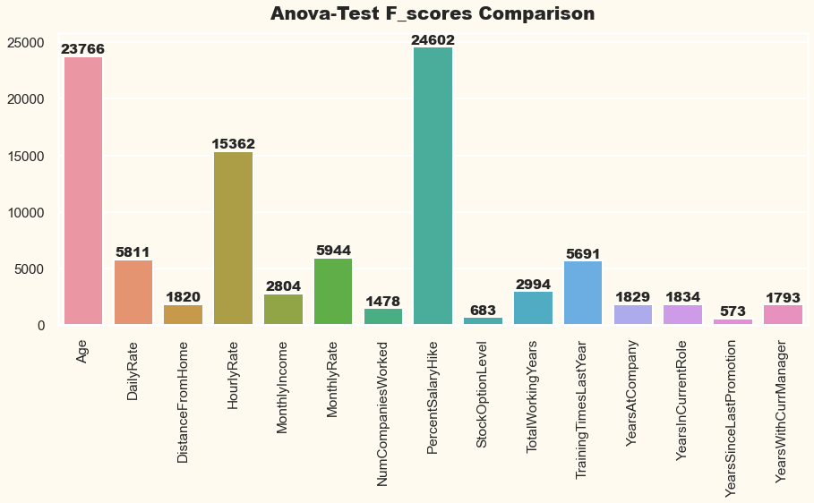

```python
plt.figure(figsize=(15,6))
keys = list(f_scores.keys())
values = list(f_scores.values())

sns.barplot(keys, values)
plt.title("Anova-Test F_scores Comparison",fontweight="black",size=20,pad=15)
plt.xticks(rotation=90)

for index,value in enumerate(values):
    plt.text(index,value,int(value), ha="center", va="bottom",fontweight="black",size=15)
plt.show()
```

## 3. Comparing F_Score and P_value of ANOVA Test.

```python
test_df = pd.DataFrame({"Features":keys,"F_Score":values})
test_df["P_value"] = list(p_values.values())
```

```python
test_df
```

|  | Features | F_Score | P_value |
| --- | --- | --- | --- |
| 0 | Age | 23766.934042 | 0.000000e+00 |
| 1 | DailyRate | 5811.796569 | 0.000000e+00 |
| 2 | DistanceFromHome | 1820.614585 | 5.314367e-310 |
| 3 | HourlyRate | 15362.122371 | 0.000000e+00 |
| 4 | MonthlyIncome | 2804.459632 | 0.000000e+00 |
| 5 | MonthlyRate | 5944.089071 | 0.000000e+00 |
| 6 | NumCompaniesWorked | 1478.188633 | 2.502519e-262 |
| 7 | PercentSalaryHike | 24602.507947 | 0.000000e+00 |
| 8 | StockOptionLevel | 683.069576 | 1.466056e-135 |
| 9 | TotalWorkingYears | 2994.906310 | 0.000000e+00 |
| 10 | TrainingTimesLastYear | 5691.401732 | 0.000000e+00 |
| 11 | YearsAtCompany | 1829.442766 | 3.485969e-311 |
| 12 | YearsInCurrentRole | 1834.262264 | 7.895023e-312 |
| 13 | YearsSinceLastPromotion | 573.896430 | 5.343223e-116 |
| 14 | YearsWithCurrManager | 1793.291314 | 2.518943e-306 |

## 4. Performing Chi-Square Test to Analyze the Categorical Feature Importance in Employee Attrition.

```python
cat_cols = df.select_dtypes(include="object").columns.tolist()
cat_cols.remove("Attrition")
```

```python
chi2_statistic = {}
p_values = {}

# Perform chi-square test for each column
for col in cat_cols:
    contingency_table = pd.crosstab(df[col], df['Attrition'])
    chi2, p_value, _, _ = chi2_contingency(contingency_table)
    chi2_statistic[col] = chi2
    p_values[col] = p_value
```

## 5. Visualizing the Chi-Square Statistic Values of Each Categorical Features.

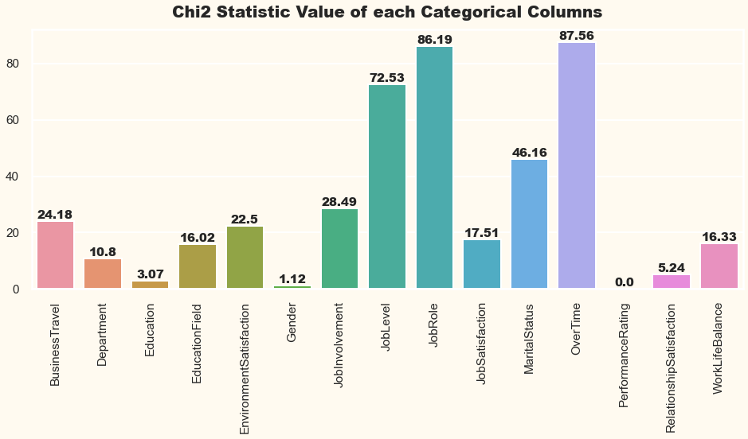

```python
columns = list(chi2_statistic.keys())
values = list(chi2_statistic.values())

plt.figure(figsize=(16,6))
sns.barplot(columns, values)
plt.xticks(rotation=90)
plt.title("Chi2 Statistic Value of each Categorical Columns",fontweight="black",size=20,pad=15)
for index,value in enumerate(values):
    plt.text(index,value,round(value,2),ha="center",va="bottom",fontweight="black",size=15)

plt.show()
```

## 6. Compairing Chi2_Statistic and P_value of Chi_Square Test.

```python
test_df = pd.DataFrame({"Features":columns,"Chi_2 Statistic":values})
test_df["P_value"] =  [format(p, '.20f') for p in list(p_values.values())]
```

```python
test_df
```

|  | Features | Chi_2 Statistic | P_value |
| --- | --- | --- | --- |
| 0 | BusinessTravel | 24.182414 | 0.00000560861447644993 |
| 1 | Department | 10.796007 | 0.00452560657447963286 |
| 2 | Education | 3.073961 | 0.54552533765659494414 |
| 3 | EducationField | 16.024674 | 0.00677398013902521211 |
| 4 | EnvironmentSatisfaction | 22.503881 | 0.00005123468906289433 |
| 5 | Gender | 1.116967 | 0.29057244902890855265 |
| 6 | JobInvolvement | 28.492021 | 0.00000286318063671342 |
| 7 | JobLevel | 72.529013 | 0.00000000000000663468 |
| 8 | JobRole | 86.190254 | 0.00000000000000275248 |
| 9 | JobSatisfaction | 17.505077 | 0.00055630045103875563 |
| 10 | MaritalStatus | 46.163677 | 0.00000000009455511060 |
| 11 | OverTime | 87.564294 | 0.00000000000000000001 |
| 12 | PerformanceRating | 0.000155 | 0.99007454659345761616 |
| 13 | RelationshipSatisfaction | 5.241068 | 0.15497244371052629197 |
| 14 | WorkLifeBalance | 16.325097 | 0.00097256988453488236 |

### 💬 Inference:

* The **following features showed statistically significant associations with employee attrition:** * **`Department`** * **`EducationField`** * **`EnvironmentSatisfaction`** * **`JobInvolvement`** * **`JobLevel`** * **`JobRole`** * **`JobSatisfaction`** * **`MaritalStatus`** * **`OverTime`** * **`WorkLifeBalance`** * The **following features did not show statistically significant associations with attrition.** * **`Gender`** * **`Education`** * **`PerformanceRating`** * **`RelationshipSatisfaction`** * **Note:** * It is **important** for the organization to **pay attention to the identified significant features and consider them when implementing strategies to reduce attrition rates.**

# **🎈 Conclusion 🎈**

### 📊 Limitations:

* The **analysis is based on the available dataset** and may **not capture all possible factors** influencing **employee attrition**. * There **could be other unmeasured** variables that **play a role in attrition.**

# **💡 Recommendations 💡**

### 📊 Recommendations:

* The below **recommendations** is based on the **key findings** related to **reducing attrition rate.** 1. **Age:** * Implement **strategies to address the specific needs and career aspirations of employees across different age groups.** * This can include **offering** targeted development opportunities, **mentorship programs**, and flexible work arrangements to **support work-life balance.** 2. **Compensation:** * Regularly **review and benchmark compensation** packages to ensure they are **competitive in the market.** * Consider incorporating performance-based **incentives and rewards to motivate employees** and recognize their contributions. 3. **Job experience:** * Provide **opportunities for career advancement**, skill development, and cross-functional training. * Establish clear career paths and **provide regular feedback** and performance evaluations to **support employee growth and engagement.** 4. **Specific job-related variables:** * **Tailor** retention strategies based on different job roles and responsibilities. * This can include **improving job satisfaction**, **providing** challenging assignments, and **fostering** a positive work environment. 5. **Job-related aspects:** * **Enhance** employee engagement and job satisfaction by **offering** a supportive work environment. * Provide **opportunities** for professional development, **promote** a culture of continuous learning, and **ensure fair and transparent** processes for **promotions and career growth.** 6. **Work-related factors:** * Focus on improving factors such as **environment satisfaction**, job involvement, job satisfaction, work-life balance, and managing overtime demands. * **Conduct regular employee surveys** to understand their concerns and feedback, and take proactive measures to address any **identified areas of improvement**. 7. **Overall:** * Foster a **positive organizational culture** that values employee well-being, work-life balance, and growth opportunities. * **Encourage** open communication, provide avenues for feedback and suggestions, and regularly evaluate and refine retention strategies based on employee feedback and changing needs.

# **🏁 THE END 🏁**

[figure not shown]